# Analyse de données sous `Python` - *correction*

```python
import numpy
import pandas
import matplotlib.pyplot as plt

# permet d'afficher les graphiques dans un notebook
%matplotlib inline
```

## Températures mondiales (anomalies)

Nous allons travailler ici sur les données de température mondiale HadCRUT4, fournies par [Climate Research Unit](https://crudata.uea.ac.uk/). Vous trouverez plus d’informations sur ces données sur ce [lien](https://crudata.uea.ac.uk/cru/data/temperature/). Nous avons ici plus exactement l'historique des anomalies moyennes mensuelles et annuelles depuis 1850, au niveau mondial, par rapport à la période de référence 1961-1990.

Le code ci-dessous télécharge directement les dernières données disponibles et les met dans un DataFrame dont vous avez un aperçu en dessous.

```python
had = pandas.read_csv("https://crudata.uea.ac.uk/cru/data/temperature/HadCRUT4-gl.dat", header=None)
donnees = pandas.DataFrame(
    [list(map(lambda v: float(v), filter(lambda v: v!= "", h.split(" ")))) for h in had[0][::2]],
    columns = ["Year", "Jan", "Feb", "Mar", "Apr", "May", "Jun", "Jul", "Aug", "Sep", "Oct", "Nov", "Dec", "Annual"]
)
donnees.tail()
```

|  | Year | Jan | Feb | Mar | Apr | May | Jun | Jul | Aug | Sep | Oct | Nov | Dec | Annual |
| --- | --- | --- | --- | --- | --- | --- | --- | --- | --- | --- | --- | --- | --- | --- |
| 165 | 2015.0 | 0.705 | 0.689 | 0.708 | 0.673 | 0.711 | 0.743 | 0.697 | 0.740 | 0.796 | 0.845 | 0.840 | 1.024 | 0.763 |
| 166 | 2016.0 | 0.934 | 1.111 | 1.106 | 0.937 | 0.707 | 0.744 | 0.744 | 0.790 | 0.729 | 0.598 | 0.553 | 0.620 | 0.797 |
| 167 | 2017.0 | 0.739 | 0.845 | 0.873 | 0.737 | 0.659 | 0.641 | 0.651 | 0.714 | 0.557 | 0.571 | 0.554 | 0.600 | 0.677 |
| 168 | 2018.0 | 0.554 | 0.528 | 0.615 | 0.627 | 0.587 | 0.573 | 0.594 | 0.586 | 0.598 | 0.678 | 0.590 | 0.638 | 0.597 |
| 169 | 2019.0 | 0.738 | 0.662 | 0.874 | 0.780 | 0.610 | 0.708 | 0.706 | 0.719 | 0.713 | 0.752 | 0.693 | 0.879 | 0.736 |

Vous devez donc réaliser les étapes suivantes, au propre dans un notebook :

- Décrire rapidement les données
  - Calculer les statistiques de base sur chaque mois et sur l'année
  - Réprésenter l'évolution des anomalies annuelles sur un graphique
- Réaliser une ACP sur les données mensuelles
- Produire les graphiques nécessaires à l’interprétation
- Identifier des années particulières
- Rechercher une partition intéressante des années
- Représenter cette partition sur le résultat de l'ACP
- Décrire les classes ainsi obtenues

Que peut-on dire globalement ?

### Description des données

#### Statistique de base sur chaque mois, et sur l'année

- Aucune donnée manquante
- Anomalies en moyenne inférieur à 0
  - plus faible en Mars, Novembre et Décembre
  - moins faible en Août
- Des gros écarts en positif sur Février, Mars et Décembre (maximum supérieur à 1)

```python
donnees.drop(columns = ("Year")).describe().round(2)
```

|  | Jan | Feb | Mar | Apr | May | Jun | Jul | Aug | Sep | Oct | Nov | Dec | Annual |
| --- | --- | --- | --- | --- | --- | --- | --- | --- | --- | --- | --- | --- | --- |
| count | 170.00 | 170.00 | 170.00 | 170.00 | 170.00 | 170.00 | 170.00 | 170.00 | 170.00 | 170.00 | 170.00 | 170.00 | 170.00 |
| mean | -0.09 | -0.09 | -0.13 | -0.09 | -0.10 | -0.07 | -0.05 | -0.04 | -0.07 | -0.08 | -0.11 | -0.12 | -0.09 |
| std | 0.36 | 0.37 | 0.37 | 0.34 | 0.31 | 0.30 | 0.29 | 0.30 | 0.30 | 0.32 | 0.34 | 0.35 | 0.31 |
| min | -0.97 | -0.78 | -0.83 | -0.72 | -0.77 | -0.58 | -0.57 | -0.70 | -0.56 | -0.71 | -0.77 | -0.89 | -0.54 |
| 25% | -0.32 | -0.35 | -0.40 | -0.34 | -0.32 | -0.28 | -0.25 | -0.25 | -0.28 | -0.32 | -0.37 | -0.36 | -0.30 |
| 50% | -0.11 | -0.15 | -0.21 | -0.17 | -0.17 | -0.14 | -0.10 | -0.09 | -0.11 | -0.11 | -0.13 | -0.17 | -0.16 |
| 75% | 0.12 | 0.14 | 0.07 | 0.09 | 0.07 | 0.07 | 0.05 | 0.08 | 0.07 | 0.07 | 0.04 | 0.13 | 0.05 |
| max | 0.93 | 1.11 | 1.11 | 0.94 | 0.71 | 0.74 | 0.74 | 0.79 | 0.80 | 0.84 | 0.84 | 1.02 | 0.80 |

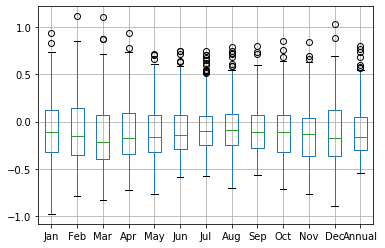

```python
donnees.drop(columns = ("Year")).boxplot()
```

#### Evolution des anomalies

On peut aussi réprésenter l'évolution des anomalies au cours du temps, pour l'ensemble des mois. Tous semblent avoir le même comportement.

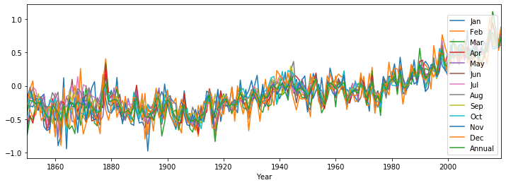

```python
donnees.plot(x = "Year", figsize = (12,4))
plt.show()
```

En se concentrant sur la moyenne annuelle des anomalies par rapport à la période de référence (1961-1990 - représentée ci-dessous), on remarque une augmentation des anomalies à partir des années 80.

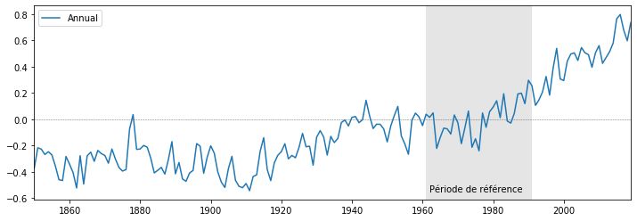

```python
fig, ax = plt.subplots()
donnees.plot(x = "Year", y = "Annual", figsize = (12,4), ax = ax)
rect = plt.Rectangle((1961, -1), 30, 2,
                     facecolor = "black", alpha = 0.1)
ax.add_patch(rect)
ax.axhline(y = 0, linewidth = .5, color = "dimgray", linestyle = "--")
ax.text(1962, -0.55, "Période de référence")
plt.xlabel("")
plt.show()
```

### ACP sur les données mensuelles

On peut appliquer l'ACP sur les données standardisées (avec la fonction `scale()`).

```python
from sklearn.decomposition import PCA
from sklearn.preprocessing import scale

donnees_mens = donnees.drop(columns = ["Year", "Annual"])
pca = PCA()
pca.fit(scale(donnees_mens))
```

```
PCA(copy=True, iterated_power='auto', n_components=None, random_state=None,
    svd_solver='auto', tol=0.0, whiten=False)
```

Le premier axe explique à lui seul 88 % de l'information.

```python
eig = pandas.DataFrame(
    {
        "Dimension" : ["Dim" + str(x + 1) for x in range(12)],
        "Variance expliquée" : pca.explained_variance_,
        "% variance expliquée" : numpy.round(pca.explained_variance_ratio_ * 100),
        "% cum. var. expliquée" : numpy.round(numpy.cumsum(pca.explained_variance_ratio_) * 100)
    }
)
eig
```

|  | Dimension | Variance expliquée | % variance expliquée | % cum. var. expliquée |
| --- | --- | --- | --- | --- |
| 0 | Dim1 | 10.679421 | 88.0 | 88.0 |
| 1 | Dim2 | 0.481996 | 4.0 | 92.0 |
| 2 | Dim3 | 0.208017 | 2.0 | 94.0 |
| 3 | Dim4 | 0.154925 | 1.0 | 95.0 |
| 4 | Dim5 | 0.123418 | 1.0 | 96.0 |
| 5 | Dim6 | 0.115370 | 1.0 | 97.0 |
| 6 | Dim7 | 0.076620 | 1.0 | 98.0 |
| 7 | Dim8 | 0.072008 | 1.0 | 99.0 |
| 8 | Dim9 | 0.044102 | 0.0 | 99.0 |
| 9 | Dim10 | 0.041565 | 0.0 | 99.0 |
| 10 | Dim11 | 0.037675 | 0.0 | 100.0 |
| 11 | Dim12 | 0.035891 | 0.0 | 100.0 |

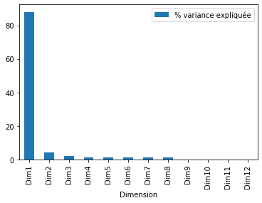

```python
eig.plot.bar(x = "Dimension", y = "% variance expliquée") # permet un diagramme en barres
plt.show()
```

```python
donnees_pca = pca.transform(donnees_mens)
donnees_pca_df = pandas.DataFrame({
    "Dim1" : donnees_pca[:,0],
    "Dim2" : donnees_pca[:,1],
    "Year" : donnees["Year"]
})
donnees_pca_df.head()
```

|  | Dim1 | Dim2 | Year |
| --- | --- | --- | --- |
| 0 | -1.297973 | -0.410539 | 1850.0 |
| 1 | -0.767006 | -0.432866 | 1851.0 |
| 2 | -0.800260 | -0.501338 | 1852.0 |
| 3 | -0.944255 | 0.036396 | 1853.0 |
| 4 | -0.873591 | -0.134763 | 1854.0 |

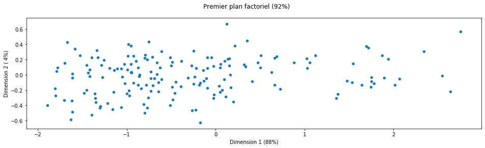

```python
# utilisation de subplots nécessaire car annotation du graphique
fig, ax = plt.subplots(figsize = (16,4))
donnees_pca_df.plot.scatter("Dim1", "Dim2", ax = ax) # l'option ax permet de placer les points et le texte sur le même graphique

# boucle sur chaque pays
for k in donnees_pca_df.iterrows():
    # annotation uniquement si valeur absolue sur une de 2 dimensions importantes (valeurs choisies empiriquement)
    if (abs(k[1]['Dim1']) > 8) | (abs(k[1]['Dim2']) > 1.5):
        ax.annotate(int(k[1]["Year"]), (k[1]['Dim1'], k[1]['Dim2']), fontsize = 9)
plt.xlabel("Dimension 1 (88%)")
plt.ylabel("Dimension 2 ( 4%)")
plt.suptitle("Premier plan factoriel (92%)")
plt.show()
```

En représentant les mois, on remarque qu'ils sont tous situés à droite du plan factoriel. Cela confirme bien que les dernières années sont celles avec des valeurs les plus élevées.

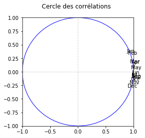

```python
n = donnees_mens.shape[0] # nb individus
p = donnees_mens.shape[1] # nb variables
eigval = (n-1) / n * pca.explained_variance_ # valeurs propres
sqrt_eigval = numpy.sqrt(eigval) # racine carrée des valeurs propres
corvar = numpy.zeros((p,p)) # matrice vide pour avoir les coordonnées
for k in range(p):
    corvar[:,k] = pca.components_[k,:] * sqrt_eigval[k]
# on modifie pour avoir un dataframe
coordvar = pandas.DataFrame({'id': donnees_mens.columns, 'COR_1': corvar[:,0], 'COR_2': corvar[:,1]})


fig, axes = plt.subplots(figsize = (4,4))
fig.suptitle("Cercle des corrélations")
axes.set_xlim(-1, 1)
axes.set_ylim(-1, 1)
# Ajout des axes
axes.axvline(x = 0, color = 'lightgray', linestyle = '--', linewidth = 1)
axes.axhline(y = 0, color = 'lightgray', linestyle = '--', linewidth = 1)
# Ajout des noms des variables
for j in range(p):
    axes.text(coordvar["COR_1"][j],coordvar["COR_2"][j], coordvar["id"][j])
# Ajout du cercle
plt.gca().add_artist(plt.Circle((0,0),1,color='blue',fill=False))

plt.show()
```

### Classification des années

On peut chercher maintenant une partition des années sur la base de ces anomalies.

```python
from sklearn.cluster import AgglomerativeClustering

hac = AgglomerativeClustering(distance_threshold=0, n_clusters=None)
hac.fit(scale(donnees_mens))
```

```
AgglomerativeClustering(affinity='euclidean', compute_full_tree='auto',
                        connectivity=None, distance_threshold=0, linkage='ward',
                        memory=None, n_clusters=None)
```

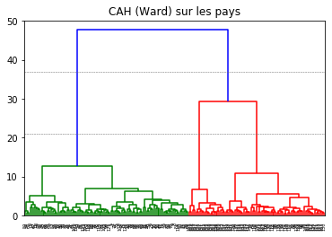

```python
from scipy.cluster.hierarchy import dendrogram

def plot_dendrogram(model, **kwargs):
    # Create linkage matrix and then plot the dendrogram

    # create the counts of samples under each node
    counts = numpy.zeros(model.children_.shape[0])
    n_samples = len(model.labels_)
    for i, merge in enumerate(model.children_):
        current_count = 0
        for child_idx in merge:
            if child_idx < n_samples:
                current_count += 1  # leaf node
            else:
                current_count += counts[child_idx - n_samples]
        counts[i] = current_count

    linkage_matrix = numpy.column_stack([model.children_, model.distances_,
                                      counts]).astype(float)

    # Plot the corresponding dendrogram
    dendrogram(linkage_matrix, **kwargs)
plt.title("CAH (Ward) sur les pays")
# plot the top three levels of the dendrogram
plot_dendrogram(hac)
plt.axhline(y = 37, linewidth = .5, color = "dimgray", linestyle = "--")
plt.axhline(y = 21, linewidth = .5, color = "dimgray", linestyle = "--")
plt.show()
```

Sur le graphique ci-dessous, on remarque qu'on peut choisir soit 2 classes, soit 3 classes. Ici, nous allons choisir 3 classes.

```python
from sklearn.cluster import KMeans

kmeans3 = KMeans(n_clusters = 3)
kmeans3.fit(scale(donnees_mens))
```

```
KMeans(algorithm='auto', copy_x=True, init='k-means++', max_iter=300,
       n_clusters=3, n_init=10, n_jobs=None, precompute_distances='auto',
       random_state=None, tol=0.0001, verbose=0)
```

Ces trois classes se répartissent comme suit :

```python
donnees_k3 = donnees_mens.assign(classe = kmeans3.labels_)
donnees_k3.groupby("classe").mean()
```

| classe | Jan | Feb | Mar | Apr | May | Jun | Jul | Aug | Sep | Oct | Nov | Dec |
| --- | --- | --- | --- | --- | --- | --- | --- | --- | --- | --- | --- | --- |
| 0 | -0.325306 | -0.350859 | -0.399800 | -0.344565 | -0.331894 | -0.294106 | -0.254988 | -0.263647 | -0.289106 | -0.318224 | -0.362659 | -0.369188 |
| 1 | 0.483500 | 0.519115 | 0.535577 | 0.525269 | 0.459115 | 0.487577 | 0.492269 | 0.509846 | 0.480962 | 0.501077 | 0.486500 | 0.460846 |
| 2 | 0.007814 | 0.005746 | -0.036153 | -0.000814 | -0.015407 | 0.006085 | 0.008746 | 0.026576 | 0.015153 | 0.018068 | -0.014661 | -0.011966 |

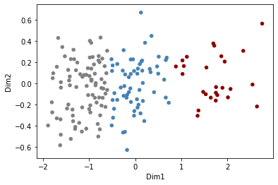

```python
col = { 0: "gray", 1: "darkred", 2: "steelblue"}
donnees_pca_k3 = donnees_pca_df.assign(classe = kmeans3.labels_)
donnees_pca_k3.plot.scatter(x = "Dim1", y = "Dim2", c = [col[k] for k in kmeans3.labels_])
plt.show()
```

### Conclusion

Il semble ainsi clair qu'il y a un échauffement global de la planète, en particulier sur les dernières années comme on peut le voir sur le graphique ci-dessous.

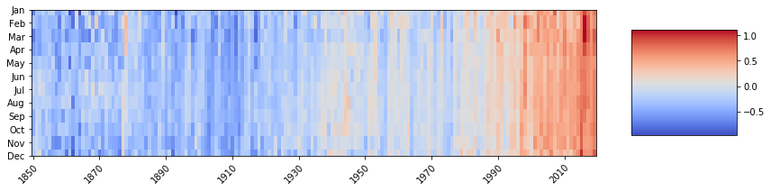

```python
donnees_trans = donnees.drop(columns =["Year", "Annual"]).transpose()

fig, ax = plt.subplots(figsize = (12, 8))
im = ax.imshow(donnees_trans, cmap = "coolwarm", aspect = 4)

locs, labels = plt.xticks()
ax.set_xticklabels([int(l) for l in locs + 1850])

month = list(donnees.columns[1:13])
ax.set_yticks(numpy.arange(len(month)))
ax.set_yticklabels(month)

plt.setp(ax.get_xticklabels(), rotation = 45, ha = "right", rotation_mode = "anchor")

fig.colorbar(im, aspect = 1)

fig.tight_layout()
plt.show()
```